# Lecture 9: Simple Linear Regression

PSTAT100: Data Science — Concepts and Analysis

John Inston

johninston@ucsb.edu

University of California, Santa Barbara

October 16, 2026

## 🚁 Overview

### Aims of the lecture

- Understand **regression** as estimation of the conditional expectation $\mathbb{E}[Y \mid X]$.
- Specify the **simple linear regression (SLR) model** and the Gauss-Markov assumptions.
- Derive the **ordinary least squares (OLS)** estimators analytically.
- Understand the **properties** of OLS: unbiasedness, sampling variance, and BLUE.
- Conduct **inference** — $t$-tests and confidence intervals — on regression coefficients.
- Measure **goodness of fit** using the SST/SSR/SSE decomposition and $R^2$.
- Distinguish **confidence intervals** from **prediction intervals** for new data.

### 📚 Required Libraries

In this lecture we will be using the following libraries:

```python
import numpy as np
import matplotlib.pyplot as plt
import seaborn as sns
from scipy.stats import t as t_dist
```

### 💅 Figure Styles

```python
sns.set_style('whitegrid')
sns.set_palette('Set2')
```

# Introduction to Linear Regression

## 🔍 What is Regression?

### Connecting to what we know

- In **Lecture 7** we introduced the conditional expectation $\mathbb{E}[Y \mid X = x]$: the expected value of $Y$ when $X$ is fixed at $x$.
- This is the **regression function** — the theoretically optimal prediction of $Y$ given $X$.

**Regression**

**Regression** is the task of estimating the conditional expectation function $\mu(x) = \mathbb{E}[Y \mid X = x]$ from observed data $(x_1, y_1), \ldots, (x_n, y_n)$.

### Why impose linearity?

- The true function $\mu(x)$ could take any shape, but we cannot estimate it without assumptions.
- **Linear regression** restricts the model to $\mu(x) = \beta_0 + \beta_1 x$ — a straight line.
- This is a **modelling choice**: it is interpretable, tractable with small $n$, and often a reasonable local approximation.

## Types of Regression

### Simple vs. multiple

- **Simple linear regression (SLR)**: one predictor $X$. This lecture.
- **Multiple linear regression (MLR)**: $p$ predictors $X_1, \ldots, X_p$. Lecture 11.

### Linear vs. nonlinear

- “Linear” refers to linearity in the **parameters** $\beta$, not necessarily in $X$ itself.
  - $Y = \beta_0 + \beta_1 X^2$ is still a linear model (we treat $X' = X^2$ as the predictor).
  - $Y = \beta_0 \exp(\beta_1 X)$ is nonlinear in $\beta$ and requires different methods.
- Much of machine learning can be viewed as flexible, nonlinear regression.

### Regression in the supervised learning framework

| Task | Response $Y$ | Example |
| --- | --- | --- |
| **Regression** | Continuous | House price, temperature, body mass |
| **Classification** | Categorical | Spam / not-spam, tumour type |

# The Simple Linear Regression Model

## 📐 The Statistical Model

**Simple Linear Regression Model**

We assume the data-generating process is:
$$Y_i = \beta_0 + \beta_1 x_i + \varepsilon_i, \qquad i = 1, \ldots, n,$$
where:

- $x_i$ is the **observed** predictor value (treated as fixed / non-random).
- $Y_i$ is the **response** (random).
- $\beta_0$ is the **intercept** — the expected value of $Y$ when $x = 0$.
- $\beta_1$ is the **slope** — the expected change in $Y$ per one-unit increase in $x$.
- $\varepsilon_i$ is the **error** — the deviation of $Y_i$ from the line; captures all unexplained variability.

### Two components of the model

- **Systematic part** $\beta_0 + \beta_1 x_i$: the signal we want to estimate.
- **Random part** $\varepsilon_i$: the noise we want to characterise and account for.

## The Gauss-Markov Assumptions

### Four conditions for classical linear regression

1. **Linearity**: $\mathbb{E}[\varepsilon_i] = 0$ for all $i$.
   - The true conditional mean is a linear function of $x$.
2. **Independence**: $\varepsilon_1, \ldots, \varepsilon_n$ are mutually independent.
   - Errors from different observations do not influence one another.
3. **Homoscedasticity**: $\text{Var}(\varepsilon_i) = \sigma^2$ for all $i$.
   - The spread of errors is constant across all values of $x$.
4. **Normality**: $\varepsilon_i \sim \mathcal{N}(0, \sigma^2)$.
   - Errors are normally distributed. Required for exact inference with small $n$; asymptotically justified by the CLT for large $n$.

Together, 1–4 imply that
$$Y_i \stackrel{\text{iid}}\sim \mathcal{N}
(\beta_0 + \beta_1 x_i,\, \sigma^2).$$

## Visualising the SLR Model

```python
rng = np.random.default_rng(42)
n, beta0_true, beta1_true, sigma_true = 80, 2.0, 1.5, 2.5
x = rng.uniform(0, 10, size=n)
y = beta0_true + beta1_true * x + rng.normal(0, sigma_true, size=n)

x_line = np.linspace(0, 10, 200)

fig, ax = plt.subplots(figsize=(10, 5))
ax.scatter(x, y, alpha=0.6, color='steelblue', label='Observed data $(x_i, Y_i)$', zorder=3)
ax.plot(x_line, beta0_true + beta1_true * x_line, color='crimson', lw=2.5,
        label=rf'True line: $\mu(x) = {beta0_true} + {beta1_true}x$')
ax.set_xlabel('$x$')
ax.set_ylabel('$Y$')
ax.set_title('Simulated SLR Data')
ax.legend()
plt.tight_layout()
plt.show()
```

## Visualising the SLR Model

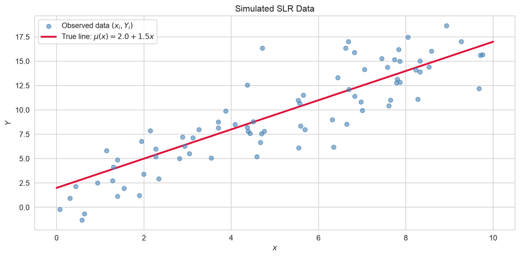

Simulated data from Y = 2 + 1.5x + ε (ε ~ N(0, 2.5²)). The true line is shown in red.

## Visualising the Error Term

```python
fig, ax = plt.subplots(figsize=(10, 5))
ax.scatter(x, y, alpha=0.5, color='steelblue', zorder=3)
ax.plot(x_line, beta0_true + beta1_true * x_line, color='crimson', lw=2.5,
        label='True line $\\mu(x)$')

# Show errors for a selection of points
rng_idx = np.random.default_rng(0)
show_idx = rng_idx.choice(n, size=14, replace=False)
for i in show_idx:
    mu_i = beta0_true + beta1_true * x[i]
    ax.plot([x[i], x[i]], [mu_i, y[i]], color='darkorange', lw=1.5, zorder=2)

ax.plot(
  [], [],
  color='darkorange',
  lw=1.5,
  label='Error $\\varepsilon_i = Y_i - \\mu(x_i)$'
  )
ax.set_xlabel('$x$')
ax.set_ylabel('$Y$')
ax.set_title('Errors: Vertical Deviations from the True Line')
ax.legend()
plt.tight_layout()
plt.show()
```

## Visualising the Error Term

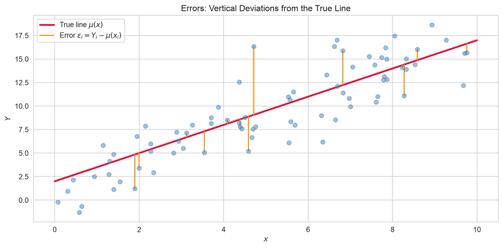

Errors εᵢ are the vertical deviations of each observation from the true line.

# Ordinary Least Squares Estimation

## 🎯 The OLS Criterion

### Choosing the best-fitting line

- In practice $\beta_0$ and $\beta_1$ are **unknown** and must be **estimated** from data.
- For any candidate line $\hat{y} = b_0 + b_1 x$, the **residual** for observation $i$ is:
  $$e_i = y_i - (b_0 + b_1 x_i).$$

**Ordinary Least Squares (OLS)**

The **OLS estimators** $\hat{\beta}_0$ and $\hat{\beta}_1$ minimise the **residual sum of squares**:
$$\text{RSS}(b_0, b_1) = \sum_{i=1}^n \bigl(y_i - b_0 - b_1 x_i\bigr)^2.$$

- Squaring makes the criterion **differentiable** and penalises large deviations heavily.
- It yields **closed-form** estimators — we can solve **analytically** by setting derivatives to zero.

## Deriving the OLS Estimators

### Setting partial derivatives to zero

Taking $\partial \text{RSS}/\partial b_0 = 0$ and $\partial \text{RSS}/\partial b_1 = 0$:

$$-2\sum_{i=1}^n (y_i - b_0 - b_1 x_i) = 0,\quad \& \quad
-2\sum_{i=1}^n x_i(y_i - b_0 - b_1 x_i) = 0.$$

Solving these **normal equations** gives:

$$\boxed{\hat{\beta}_1 = \frac{S_{xy}}{S_{xx}}, \qquad
\hat{\beta}_0 = \bar{y} - \hat{\beta}_1\,\bar{x},}$$

where $S_{xx} = \sum_{i=1}^n (x_i - \bar{x})^2$ and $\quad S_{xy} = \sum_{i=1}^n (x_i - \bar{x})(y_i - \bar{y})$.

### Key insights

- The OLS line always passes through the **sample means** $(\bar{x}, \bar{y})$.
- $\hat{\beta}_1$ is proportional to the **sample covariance** of $x$ and $y$.

## Relationship to MLE under Normality

If we assume GM1–GM4 then
$$Y_i \sim \mathcal{N}(\beta_0 + \beta_1 x_i,\, \sigma^2),
\quad i = 1, \ldots, n.$$

The **likelihood function** is:
$$\begin{aligned}
L(\beta_0, \beta_1, \sigma^2) = \prod_{i=1}^n f_Y(y_i)
= (2\pi\sigma^2)^{-\frac{n}{2}}
\exp\left(-\frac{1}{2\sigma^2}
\sum_{i=1}^n(y_i - \beta_0 - \beta_1 x_i)^2\right).
\end{aligned}$$

The **log-likelihood function** is:
$$l(\beta_0, \beta_1, \sigma^2) = -\frac{n}{2}\log(2\pi\sigma^2) - \frac{1}{2\sigma^2} \underbrace{\sum_{i=1}^n (y_i - \beta_0 - \beta_1 x_i)^2}_{\text{RSS}}.$$

Maximizing $L$ with respect to $\beta_0$ and $\beta_1$ is **equivalent** to minimizing the RSS, so:
$$\hat{\beta}_0^{\text{MLE}} = \hat{\beta}_0^{\text{OLS}}, \qquad
\hat{\beta}_1^{\text{MLE}} = \hat{\beta}_1^{\text{OLS}}.$$

## Computing OLS from Scratch

```python
# Step 1: Compute the sufficient statistics
x_bar = x.mean()
y_bar = y.mean()
S_xx = np.sum((x - x_bar)**2)
S_xy = np.sum((x - x_bar) * (y - y_bar))

# Step 2: OLS slope and intercept
beta1_hat = S_xy / S_xx
beta0_hat = y_bar - beta1_hat * x_bar

print(f"True:      β₀ = {beta0_true:.2f},  β₁ = {beta1_true:.2f}")
print(f"Estimated: β̂₀ = {beta0_hat:.3f}, β̂₁ = {beta1_hat:.3f}")

# Step 3: Plot
fig, ax = plt.subplots(figsize=(10, 5))
ax.scatter(x, y, alpha=0.4, color='steelblue', label='Data', zorder=3)
ax.plot(x_line, beta0_true + beta1_true * x_line, 'crimson', lw=2, label='True line')
ax.plot(x_line, beta0_hat + beta1_hat * x_line, 'navy', lw=2, linestyle='--',
        label=f'OLS fit: $\\hat{{y}} = {beta0_hat:.2f} + {beta1_hat:.2f}x$')
ax.set_xlabel('$x$'); ax.set_ylabel('$Y$')
ax.legend(); plt.tight_layout(); plt.show()
```

## Computing OLS from Scratch

```
True:      β₀ = 2.00,  β₁ = 1.50
Estimated: β̂₀ = 1.103, β̂₁ = 1.616
```

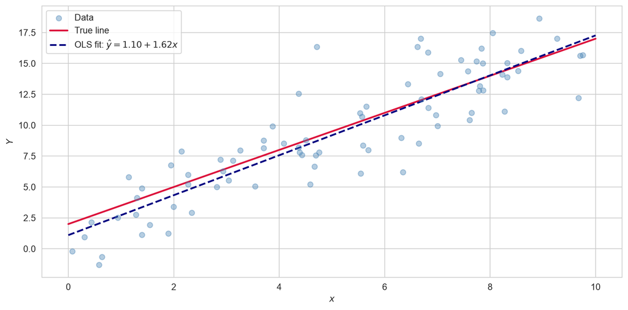

OLS estimated line (navy dashed) vs. the true line (red). With n=80 observations the estimate is very close.

## Fitted Values and Residuals

**Fitted Values and Residuals**

The **fitted value** for observation $i$ is $\hat{y}_i = \hat{\beta}_0 + \hat{\beta}_1 x_i$.

The **residual** is the difference between the observed and fitted response:
$$e_i = y_i - \hat{y}_i.$$

- The residuals satisfy the following properties:
  - $\sum_{i=1}^n e_i = 0$: residuals sum to zero.
  - $\sum_{i=1}^n x_i e_i = 0$: residuals are uncorrelated with $x$.
  - $\sum_{i=1}^n \hat{y}_i\, e_i = 0$: residuals are uncorrelated with fitted values.
- These three identities follow directly from the normal equations.

```python
y_hat = beta0_hat + beta1_hat * x
residuals = y - y_hat
print(f"Σ eᵢ = {residuals.sum():.2e}")
print(f"Σ xᵢ eᵢ = {(x * residuals).sum():.2e}")
print(f"Σ ŷᵢ eᵢ = {(y_hat * residuals).sum():.2e}")
```

```
Σ eᵢ = -3.55e-14
Σ xᵢ eᵢ = -1.99e-13
Σ ŷᵢ eᵢ = -4.55e-13
```

## Visualising Residuals

```python
fig, ax = plt.subplots(figsize=(10, 5))
ax.scatter(x, y, alpha=0.4, color='steelblue', zorder=3, label='Data')
ax.plot(x_line, beta0_hat + beta1_hat * x_line, 'navy', lw=2, label='OLS fit')

rng_idx2 = np.random.default_rng(1)
show_idx2 = rng_idx2.choice(n, size=16, replace=False)
for i in show_idx2:
    ax.plot([x[i], x[i]], [y_hat[i], y[i]], color='darkorange', lw=1.5, zorder=2)

ax.plot([], [], color='darkorange', lw=1.5, label='Residual $e_i = y_i - \\hat{y}_i$')
ax.set_xlabel('$x$'); ax.set_ylabel('$Y$')
ax.set_title('OLS Residuals: Vertical Deviations from the Fitted Line')
ax.legend()
plt.tight_layout()
plt.show()
```

## Visualising Residuals

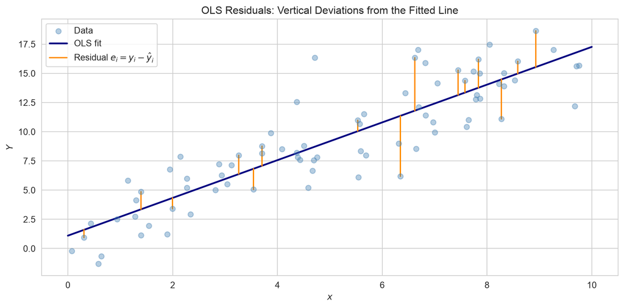

Residuals eᵢ are the vertical distances from each data point to the OLS line.

# Properties of OLS Estimators

## ✅ Unbiasedness

### OLS recovers the true parameters on average

We can write $\hat{\beta}_1 = \sum_{i=1}^n c_i Y_i$ where $c_i = (x_i - \bar{x})/S_{xx}$ (linear combination).

Since $Y_i = \beta_0 + \beta_1 x_i + \varepsilon_i$ and $\mathbb{E}[\varepsilon_i] = 0$:

$$\begin{aligned}
\mathbb{E}[\hat{\beta}_1] & = \sum_{i=1}^n c_i \mathbb{E}[Y_i]
= \beta_0\underbrace{\sum_{i=1}^n c_i}_{=\frac{n\bar{x}-n\bar{x}}{S_{xx}}=0}
+ \beta_1 \underbrace{\sum_{i=1}^nc_ix_i}_{=\frac{S_{xx}}{S_{xx}}=1}
= \beta_1. \quad \checkmark
\end{aligned}$$

An analogous argument gives $\mathbb{E}[\hat{\beta}_0] = \beta_0$.

- Both estimators are **unbiased** under GM1–GM3. **Normality (GM4) is not needed.**
- On average across many datasets, OLS will return the true parameter values.

## Sampling Variance of OLS Estimators

Under GM1–GM4, the exact sampling variances are:

$$\text{Var}(\hat{\beta}_1) = \frac{\sigma^2}{S_{xx}}, \qquad \text{Var}(\hat{\beta}_0) = \sigma^2\!\left(\frac{1}{n} + \frac{\bar{x}^2}{S_{xx}}\right).$$

### What drives precision?

| Factor | Effect on $\text{Var}(\hat{\beta}_1)$ |
| --- | --- |
| More spread in $x$ (↑ $S_{xx}$) | ↓ Variance — better leverage |
| Larger sample size (↑ $n$) | ↓ Variance — more information |
| Less noise (↓ $\sigma^2$) | ↓ Variance — cleaner signal |

### Estimating $\sigma^2$

Since $\sigma^2$ is unknown, we estimate it with the **residual variance**:
$$\hat{\sigma}^2 = \frac{\text{RSS}}{n - 2}.$$

We divide by $n - 2$ (not $n$) because estimating $\hat{\beta}_0$ and $\hat{\beta}_1$ costs **two degrees of freedom**.

## The Gauss-Markov Theorem

**Gauss-Markov Theorem**

Under assumptions GM1–GM3 (linearity, independence, homoscedasticity — **normality is not required**), the OLS estimators $\hat{\beta}_0$ and $\hat{\beta}_1$ are **BLUE**:

**B**est **L**inear **U**nbiased **E**stimators.

### Unpacking “BLUE”

- **Linear**: the estimator is a linear function of the responses $Y_1, \ldots, Y_n$.
- **Unbiased**: $\mathbb{E}[\hat{\beta}_j] = \beta_j$ (as shown above).
- **Best**: among *all* linear unbiased estimators, OLS has the **smallest variance**.

### The practical message

- We don’t need normality for OLS to be the optimal linear estimator.
- Normality is only needed for **exact** $t$-based inference in small samples.
- For large $n$, the CLT justifies normal-based inference regardless.

## Simulating OLS Properties

```python
rng2 = np.random.default_rng(7)
beta1_sims = []
for _ in range(2000):
    y_sim   = beta0_true + beta1_true * x + rng2.normal(0, sigma_true, size=n)
    S_xy_s  = np.sum((x - x_bar) * (y_sim - y_sim.mean()))
    beta1_sims.append(S_xy_s / S_xx)

beta1_sims      = np.array(beta1_sims)
theoretical_se  = sigma_true / np.sqrt(S_xx)

fig, ax = plt.subplots(figsize=(10, 5))
sns.histplot(beta1_sims, bins=45, kde=True, color='steelblue', ax=ax)
ax.axvline(beta1_true, color='crimson', lw=2.5, linestyle='--',
           label=f'True β1 = {beta1_true}')
ax.axvline(beta1_sims.mean(), color='navy', lw=2, linestyle=':',
label=f'Mean β̂1 = {beta1_sims.mean():.3f}  (unbiased: True)')
ax.set_xlabel(r'$\hat{\beta}_1$'); ax.set_ylabel('Density')
ax.set_title(f'Sampling Distribution of $\\hat{{\\beta}}_1$   '
             f'(theoretical SE = {theoretical_se:.3f},  empirical SE = {beta1_sims.std():.3f})')
ax.legend()
plt.tight_layout()
plt.show()
```

## Simulating OLS Properties

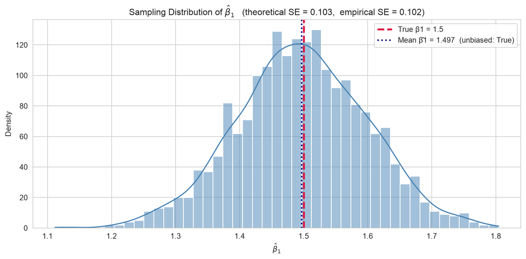

Sampling distribution of β̂₁ across 2 000 simulated datasets. The estimator is centred on the true value β₁ = 1.5.

# Statistical Inference for Regression

## 📊 The Sampling Distribution of $\hat{\beta}_1$

### Under normality (GM4)

Since $\hat{\beta}_1 = \sum_i c_i Y_i$ is a linear combination of independent normals:

$$\hat{\beta}_1 \sim \mathcal{N}\!\left(\beta_1,\; \frac{\sigma^2}{S_{xx}}\right).$$

- The degrees of freedom are $n - 2$ because we estimated **two** parameters ($\beta_0$ and $\beta_1$).
- An analogous result holds for $\hat{\beta}_0$ with its own standard error.

## $t$-Tests for Regression Coefficients

### Testing whether a predictor has a linear effect

The most common test is:
$$H_0: \beta_1 = 0 \quad \text{vs.} \quad H_1: \beta_1 \neq 0.$$

If $\beta_1 = 0$, then $X$ has **no linear association** with $Y$ in the population.

### Test statistic and $p$-value

$$T = \frac{\hat{\beta}_1}{s_{\hat{\beta}_1}} \sim t_{n-2} \quad \text{under } H_0.$$

$p\text{-value} = 2\mathbb{P}(t_{n-2} \geq |T_{\text{obs}}|).$

```python
RSS = np.sum(residuals**2)
sigma_hat = np.sqrt(RSS / (n - 2))
SE_b1 = sigma_hat / np.sqrt(S_xx)
SE_b0 = sigma_hat * np.sqrt(1/n + x_bar**2 / S_xx)

t_b1 = beta1_hat / SE_b1
p_b1 = 2 * t_dist.sf(abs(t_b1), df=n - 2)
print(f"β̂₁ = {beta1_hat:.4f},  SE = {SE_b1:.4f}")
print(f"t  = {t_b1:.3f},   p  = {p_b1:.2e}")
```

```
β̂₁ = 1.6164,  SE = 0.0968
t  = 16.691,   p  = 1.84e-27
```

## Confidence Intervals for the Coefficients

A $(1 - \alpha) \times 100\%$ confidence interval for $\beta_j$ is:

$$\hat{\beta}_j \;\pm\; t_{\alpha/2,\, n-2} \cdot s_{\hat{\beta}_j}.$$

### Interpretation

- Values of $\beta_j$ **outside** the CI are inconsistent with the data at the $\alpha$ level.
- If the CI for $\beta_1$ **excludes zero**, we reject $H_0: \beta_1 = 0$ at the same level.
- Reporting a CI is more informative than a $p$-value alone — it communicates **magnitude and uncertainty**, not just significance.

```python
alpha  = 0.05
t_crit = t_dist.ppf(1 - alpha/2, df=n - 2)

CI_b1 = (beta1_hat - t_crit * SE_b1, beta1_hat + t_crit * SE_b1)
CI_b0 = (beta0_hat - t_crit * SE_b0, beta0_hat + t_crit * SE_b0)

print(f"95% CI for β₁: ({CI_b1[0]:.3f}, {CI_b1[1]:.3f})")
print(f"95% CI for β₀: ({CI_b0[0]:.3f}, {CI_b0[1]:.3f})")
print(f"True β₁ = {beta1_true}  ← inside CI? {CI_b1[0] < beta1_true < CI_b1[1]}")
```

```
95% CI for β₁: (1.424, 1.809)
95% CI for β₀: (-0.004, 2.209)
True β₁ = 1.5  ← inside CI? True
```

# Goodness of Fit

## 📏 Decomposing Variation

### How much of $Y$’s variability does $X$ explain?

**Variance Decomposition (ANOVA Identity)**

$$\underbrace{\sum_{i=1}^n (y_i - \bar{y})^2}_{\text{SST (Total)}} = \underbrace{\sum_{i=1}^n (\hat{y}_i - \bar{y})^2}_{\text{SSR (Regression)}} + \underbrace{\sum_{i=1}^n e_i^2}_{\text{SSE (Residual)}}.$$

| Quantity | Name | Degrees of Freedom | What it measures |
| --- | --- | --- | --- |
| SST | Total SS | $n - 1$ | Total variability in $Y$ |
| SSR | Regression SS | $1$ | Variability **explained** by the model |
| SSE | Residual SS | $n - 2$ | Variability **unexplained** (error) |

## The $R^2$ Statistic

**Coefficient of Determination $R^2$**

$$R^2 = \frac{\text{SSR}}{\text{SST}} = 1 - \frac{\text{SSE}}{\text{SST}}.$$
$R^2$ is the **proportion of variance in $Y$ explained by the linear model**.

### Properties of $R^2$

- $0 \leq R^2 \leq 1$.
- $R^2 = 0$: the model explains nothing (the flat line $\hat{y} = \bar{y}$ fits just as well).
- $R^2 = 1$: all points lie exactly on the line — perfect fit.
- For SLR only: $R^2 = r^2$, the **square of the Pearson correlation coefficient**.
- A high $R^2$ does **not** mean the model assumptions are satisfied.
- $R^2$ always increases when predictors are added — addressed with **adjusted $R^2$** in Lecture 11.

## Computing $R^2$ and the Decomposition

```python
SST   = np.sum((y - y_bar)**2)
SSE_v = np.sum(residuals**2)
SSR   = SST - SSE_v
R2    = SSR / SST
r     = np.corrcoef(x, y)[0, 1]

print(f"SST = {SST:.2f}  (total)")
print(f"SSR = {SSR:.2f}  (explained)")
print(f"SSE = {SSE_v:.2f}  (residual)")
print(f"R²  = SSR/SST = {R2:.4f}")
print(f"r   = {r:.4f}  →  r² = {r**2:.4f}  ✓")

fig, ax = plt.subplots(figsize=(10, 5))
ax.scatter(x, y, alpha=0.35, color='steelblue', zorder=3, label='Data')
ax.plot(x_line, beta0_hat + beta1_hat * x_line, 'navy', lw=2, label='OLS fit $\\hat{y}$')
ax.axhline(y_bar, color='gray', lw=1.5, linestyle='--', label='$\\bar{y}$')

i0 = np.argmin(np.abs(x - 6.8))
ax.annotate('', xy=(x[i0], y[i0]),     xytext=(x[i0], y_bar),
            arrowprops=dict(arrowstyle='<->', color='crimson',    lw=2))
ax.annotate('', xy=(x[i0], y_hat[i0]), xytext=(x[i0], y_bar),
            arrowprops=dict(arrowstyle='<->', color='seagreen',   lw=2))
ax.annotate('', xy=(x[i0], y[i0]),     xytext=(x[i0], y_hat[i0]),
            arrowprops=dict(arrowstyle='<->', color='darkorange', lw=2))

ax.plot([], [], color='crimson',    label='$y_i - \\bar{y}$  (SST component)')
ax.plot([], [], color='seagreen',   label='$\\hat{y}_i - \\bar{y}$  (SSR component)')
ax.plot([], [], color='darkorange', label='$e_i$  (SSE component)')
ax.legend(fontsize=9); plt.tight_layout(); plt.show()
```

## Computing $R^2$ and the Decomposition

```
SST = 1952.34  (total)
SSR = 1525.27  (explained)
SSE = 427.07  (residual)
R²  = SSR/SST = 0.7813
r   = 0.8839  →  r² = 0.7813  ✓
```

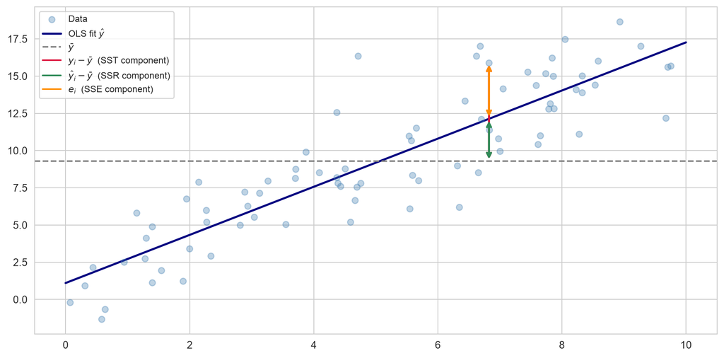

The variance decomposition for one point: SST (red) = SSR (green) + SSE (orange).

# Prediction

## 🔮 Point Predictions

### Using the fitted model for new data

For a new input $x^*$, the **point prediction** is:
$$\hat{y}^* = \hat{\beta}_0 + \hat{\beta}_1 x^*.$$

### Two different prediction questions

We may want to estimate:

1. The **average response** at $x^*$: $\mathbb{E}[Y \mid X = x^*] = \beta_0 + \beta_1 x^*$.
2. A **single new observation** $Y^*$: $Y^* = \beta_0 + \beta_1 x^* + \varepsilon^*$.

Both share the same point estimate $\hat{y}^*$, but they involve **fundamentally different uncertainties**.

## Confidence Intervals vs. Prediction Intervals

**Confidence interval for $\mathbb{E}[Y \mid X = x^*]$** — uncertainty in the *mean response*:

$$\hat{y}^* \;\pm\; t_{\alpha/2,\, n-2}\;\hat{\sigma}\sqrt{\frac{1}{n} + \frac{(x^* - \bar{x})^2}{S_{xx}}}.$$

**Prediction interval for a new observation $Y^*$** — uncertainty in a *single future value*:

$$\hat{y}^* \;\pm\; t_{\alpha/2,\, n-2}\;\hat{\sigma}\sqrt{1 + \frac{1}{n} + \frac{(x^* - \bar{x})^2}{S_{xx}}}.$$

### Key differences

- The prediction interval carries an extra $\hat{\sigma}^2$ for the **new irreducible error** $\varepsilon^*$.
- Prediction intervals are **always wider** than confidence intervals.
- Both intervals **widen as $x^*$ moves away from $\bar{x}$** — extrapolation is less certain.

## CI vs. PI in Python

```python
x_pred  = np.linspace(0, 10, 300)
y_pred  = beta0_hat + beta1_hat * x_pred
t_crit2 = t_dist.ppf(0.975, df=n - 2)

se_mean = sigma_hat * np.sqrt(1/n     + (x_pred - x_bar)**2 / S_xx)
se_pi   = sigma_hat * np.sqrt(1 + 1/n + (x_pred - x_bar)**2 / S_xx)

fig, ax = plt.subplots(figsize=(11, 5))
ax.scatter(x, y, alpha=0.4, color='steelblue', label='Data', zorder=3)
ax.plot(x_pred, y_pred, 'navy', lw=2, label='OLS fit')
ax.fill_between(x_pred,
                y_pred - t_crit2 * se_mean,
                y_pred + t_crit2 * se_mean,
                alpha=0.35, color='navy', label='95% CI for $\\mathbb{E}[Y|x^*]$')
ax.fill_between(x_pred,
                y_pred - t_crit2 * se_pi,
                y_pred + t_crit2 * se_pi,
                alpha=0.12, color='steelblue', label='95% Prediction interval')
ax.set_xlabel('$x$'); ax.set_ylabel('$Y$')
ax.set_title('Confidence Interval for the Mean Response vs. Prediction Interval')
ax.legend()
plt.tight_layout()
plt.show()
```

## CI vs. PI in Python

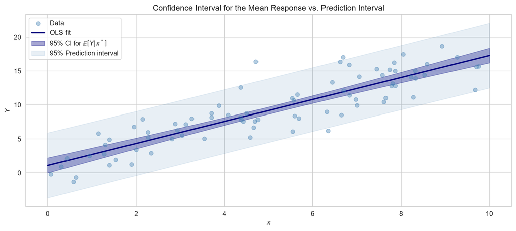

95% confidence band (dark fill) vs. 95% prediction band (light fill). The prediction band is wider because it also accounts for individual observation error.

## Summary: The SLR Workflow

| Step | Task | Key Formula / Tool |
| --- | --- | --- |
| 1. Specify | Write down the statistical model | $Y_i = \beta_0 + \beta_1 x_i + \varepsilon_i$ |
| 2. Estimate | Minimise RSS | $\hat{\beta}_1 = S_{xy}/S_{xx}$, $\hat{\beta}_0 = \bar{y} - \hat{\beta}_1\bar{x}$ |
| 3. Check properties | Verify unbiasedness, invoke Gauss-Markov | BLUE under GM1–GM3 |
| 4. Inference | $t$-tests and CIs for coefficients | $T = \hat{\beta}_1 / \widehat{\text{SE}}(\hat{\beta}_1) \sim t_{n-2}$ |
| 5. Fit quality | Decompose variation | $R^2 = \text{SSR}/\text{SST}$ |
| 6. Predict | Point estimate + interval | CI for mean vs. PI for new obs. |

## Conclusion

### ✅ What we covered

- **Regression** as estimation of $\mathbb{E}[Y \mid X]$ — connecting to Lectures 7 & 8.
- The **SLR statistical model** $Y_i = \beta_0 + \beta_1 x_i + \varepsilon_i$ and the four Gauss-Markov assumptions.
- **OLS estimation**: deriving $\hat{\beta}_0$ and $\hat{\beta}_1$ in closed form by minimising RSS.
- **Properties**: unbiasedness, sampling variances, and the Gauss-Markov theorem (BLUE).
- **Inference**: $t$-tests and confidence intervals for regression coefficients.
- **Goodness of fit**: SST/SSR/SSE decomposition and the $R^2$ statistic.
- **Prediction**: the distinction between CIs for the mean response and prediction intervals.

### 📅 What’s next?

- Applying SLR end-to-end in Python using a real dataset.
- Fitting a model with `statsmodels` and reading every line of the regression summary.
- Checking the Gauss-Markov assumptions through residual diagnostic plots.